# Untitled

Jongmin Oh

2024-10-14

## R code1: KNN (K-nearest neighbor)

```r
x = runif(100,0,4)    #0과 4 사이 값 100개 난수 생성
e = rnorm(100,0,0.15) #평균0, 표준편차 0.15인 정규분포 난수 생성

y=x+e  ## y = sin(x)+e

#simple linear regression
fit<-lm(y~x)

newd   =data.frame(x)
knnfit = FNN::knn.reg(train = x, test = newd, y = y, k = 50)
```

선형회귀모형 적합시 vs KNN으로 예측한 결과 비교하고할떄, 여기서는 k수가 많을때 예시임 KNN은 K수가 너무 많아지면 많은 이웃의 평균을 취하게 되어, 개별 데이터 포인트의 차이가 희석됨.즉, 모델이 너무 일반화되어서 패턴을 잘 못찾아내어서 예측력이 떨어짐 (과소적합) K가 너무 적으면 작은 변동에 민감해서 과적합을 초래함 일반 Plot으로 그릴 때

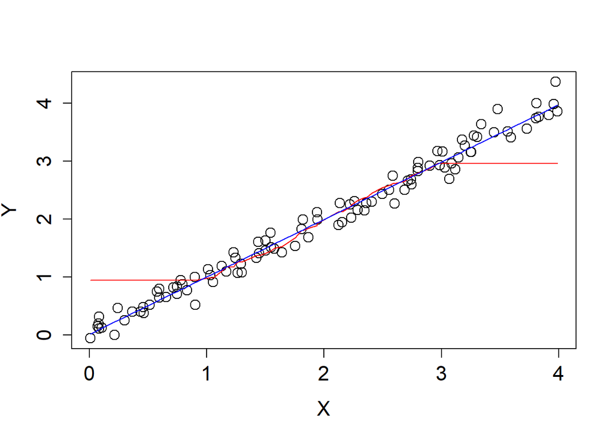

```r
plot(x,y,cex.lab=1.4,cex.axis=1.4,cex=1.5,xlab="X",ylab="Y")
ORD = order(newd$x)
lines(newd$x[ORD],knnfit$pred[ORD],col="red")
lines(newd$x[ORD],fitted(fit)[ORD],col="blue")
```

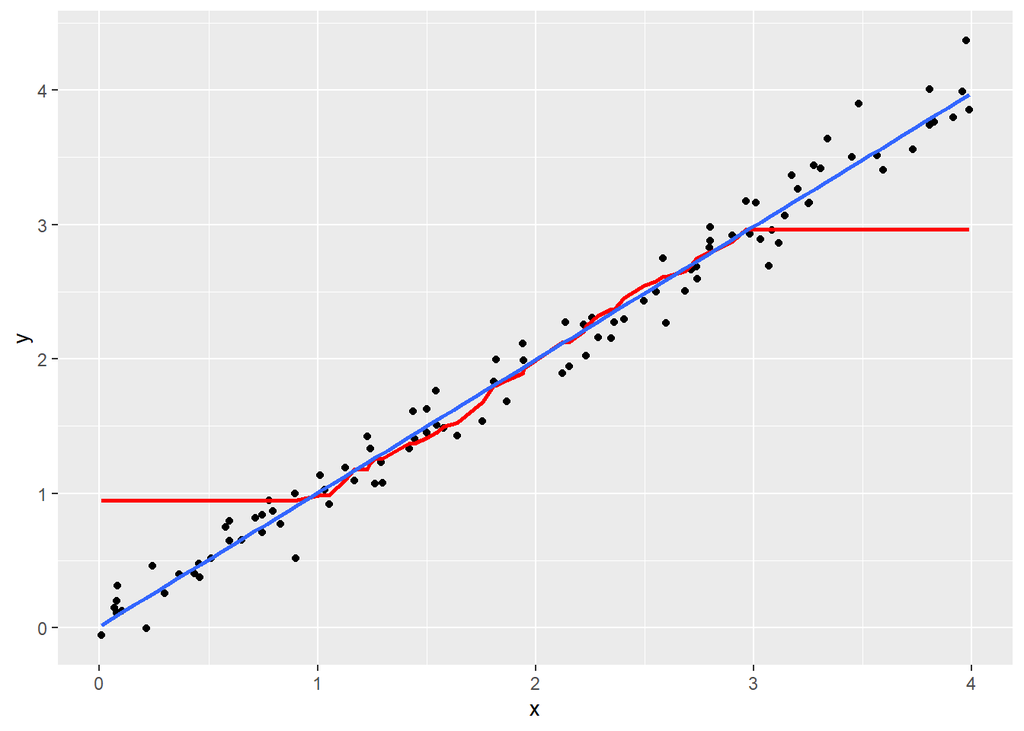

```r
#ggplot으로 그릴때
knn_ex<-data.frame(cbind(x,y,knnfit$pred))
ggplot(knn_ex,aes(x,y))+geom_point()+
  geom_line(aes(x,V3),col="red",size=1)+
  stat_smooth(method=lm,se=F,size=1)
```

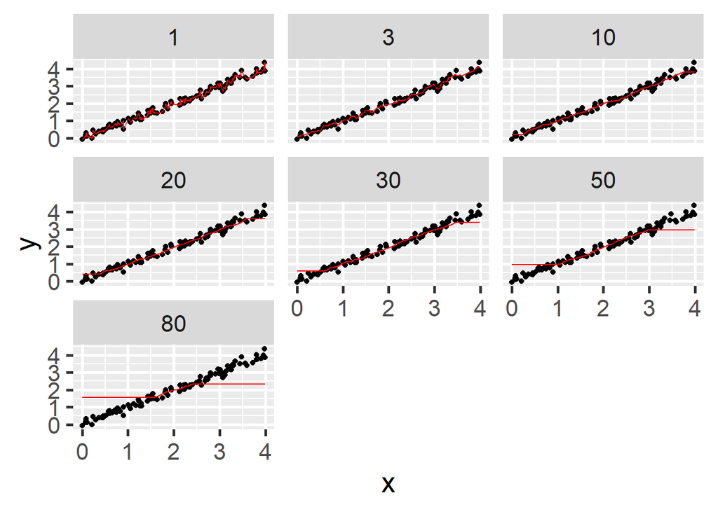

```r
#추가적으로 k 숫자에 따라 비교할 때
knnfit1 = FNN::knn.reg(train = x, test = newd, y = y, k = 1)
knnfit2 = FNN::knn.reg(train = x, test = newd, y = y, k = 3)
knnfit3 = FNN::knn.reg(train = x, test = newd, y = y, k = 5)
knnfit4 = FNN::knn.reg(train = x, test = newd, y = y, k = 10)
knnfit5 = FNN::knn.reg(train = x, test = newd, y = y, k = 20)
knnfit6 = FNN::knn.reg(train = x, test = newd, y = y, k = 30)
knnfit7 = FNN::knn.reg(train = x, test = newd, y = y, k = 50)
knnfit8 = FNN::knn.reg(train = x, test = newd, y = y, k = 80)

knn_ex2<-rbind(data.frame(x,y,pred=knnfit1$pred,k=1),
data.frame(x,y,pred=knnfit2$pred,k=3),
data.frame(x,y,pred=knnfit4$pred,k=10),
data.frame(x,y,pred=knnfit5$pred,k=20),
data.frame(x,y,pred=knnfit6$pred,k=30),
data.frame(x,y,pred=knnfit7$pred,k=50),
data.frame(x,y,pred=knnfit8$pred,k=80))

ggplot(knn_ex2,aes(x,y))+geom_point()+
  geom_line(aes(x,pred),col="red")+facet_wrap(~k)+theme_gray(base_size=20)
```

## R code2: SeparableCase

```r
#logistic regression : separable case

#example data
x<-seq(1:20)
y<-c(rep(0,10),rep(1,10)) #일부로 데이터를 이렇게 생성함
```

*#*separable case: 두 범주가 하나의 선형함수로 분리 가능한 경우 예시한 클래스가 다른 클래스와 겹치지 않는 경우, 로지스틱 회귀는 완벽한 분류를 수행함. 이 때 결정 경계는 두 클래스 데이터를 완벽하게 나눠버림; 이러한 경우 파라미터 추정값이 신뢰할 수 없는 결과로 이어질 수 있음; 즉, 오즈비가 추정은 되는데 값이 너무 크고, 불안정한 추정으로 인한 신뢰구간이 매우 넓거나 극단적일 수 있음

```r
fit<-glm(y~x,family="binomial")
summary(fit)
```

```
##
## Call:
## glm(formula = y ~ x, family = "binomial")
##
## Coefficients:
##              Estimate Std. Error z value Pr(>|z|)
## (Intercept)   -433.39  273195.81  -0.002    0.999
## x               41.28   25989.20   0.002    0.999
##
## (Dispersion parameter for binomial family taken to be 1)
##
##     Null deviance: 2.7726e+01  on 19  degrees of freedom
## Residual deviance: 4.3572e-09  on 18  degrees of freedom
## AIC: 4
##
## Number of Fisher Scoring iterations: 25
```

```r
fitted(fit)
```

```
##            1            2            3            4            5            6
## 2.220446e-16 2.220446e-16 2.220446e-16 2.220446e-16 2.220446e-16 2.220446e-16
##            7            8            9           10           11           12
## 2.220446e-16 2.220446e-16 2.220446e-16 1.089298e-09 1.000000e+00 1.000000e+00
##           13           14           15           16           17           18
## 1.000000e+00 1.000000e+00 1.000000e+00 1.000000e+00 1.000000e+00 1.000000e+00
##           19           20
## 1.000000e+00 1.000000e+00
```

```r
table(y,as.numeric(fitted(fit)>0.5)) #결과가 안벽히 분류하니 accuracy도 100으로 산출
```

```
##
## y    0  1
##   0 10  0
##   1  0 10
```

```r
#### lda
library(MASS)
#LDA 예시, 각 클래스의 사전 확률이 1/2, 1/2이라고 하자
res.lda <- lda(y ~ x , prior = c(1,1)/2)
res.lda <- lda(y ~ x , prior = c(0.5, 0.5)) #위랑 같은 애기

#마찬가지로 separable case에서 LDA 결과 비교
predict(res.lda)$class
```

```
##  [1] 0 0 0 0 0 0 0 0 0 0 1 1 1 1 1 1 1 1 1 1
## Levels: 0 1
```

```r
table(y,predict(res.lda)$class)
```

```
##
## y    0  1
##   0 10  0
##   1  0 10
```

```r
# Firth's correction
#완전 분리 문제를 해결하기위해 사용하는 방법
#Firth의 수정은 Jeffreys prior라는 베이지안 접근 방식을 사용하여
#로지스틱 회귀의 우도함수(likelihood function)에 수정 항을 추가.
#이 수정은 최대 우도 추정(MLE)의 성질을 유지하면서 파라미터 추정의 안정성을 높이는 효과
library(logistf)
fit<-logistf(y~x)
summary(fit)
```

```
## logistf(formula = y ~ x)
##
## Model fitted by Penalized ML
## Coefficients:
##                   coef  se(coef)  lower 0.95 upper 0.95    Chisq           p
## (Intercept) -8.9500486 4.3787349 -38.9500486  -2.634133 15.73885 7.27154e-05
## x            0.8523856 0.4092118   0.2672489   3.709528 19.03369 1.28431e-05
##             method
## (Intercept)      2
## x                2
##
## Method: 1-Wald, 2-Profile penalized log-likelihood, 3-None
##
## Likelihood ratio test=19.03369 on 1 df, p=1.28431e-05, n=20
## Wald test = 4.338862 on 1 df, p = 0.03725182
```

```r
table(y,as.numeric(fit$predict>0.5))
```

```
##
## y    0  1
##   0 10  0
##   1  0 10
```

## R code3: knn

```r
pacman::p_load(ISLR)
data(Default) #ISLR 교재 예제 자료인듯

#Default: 신용카드 대금 연체여부 예측하는 분류문제 사용되는 예시 문제
#고객 특성을 바탕으로 신용카드 대금 연체(default)여부 예측이 주 목표
#student: 독립변수, 고객이 학생인지 아닌지 (No/Yes)
#balance: 독립변수, 고객이 월간 결제 후에 신용카드 잔액(평균), 값이 클수록 연체가능성이 높음
#         값이 높으면 카드 사용 후 결제하지 않은 금액이 많다는 것을 의미
#income : 독립변수, 고객의 연소득, 소득 수준이 높을수록 연체가능성이 낮아질 수 있음


#비복원 추출로 sample 1~10000사이 중 7000개 추출
set.seed(1234)
train.row <- sample(1:10000, 7000,replace=F)

head(Default)
```

```
##   default student   balance    income
## 1      No      No  729.5265 44361.625
## 2      No     Yes  817.1804 12106.135
## 3      No      No 1073.5492 31767.139
## 4      No      No  529.2506 35704.494
## 5      No      No  785.6559 38463.496
## 6      No     Yes  919.5885  7491.559
```

```r
#balance랑 income 변수만 샘플링해서 train, test 추출
#단위는 1000으로 조정해줌
trainD<-Default[train.row ,3:4]/1000
testD <-Default[-train.row,3:4]/1000

trainY<-Default[train.row,1]
testY <-Default[-train.row,1]

library(class)
#KNN을 이용한 분류모델 적용
#k는 이웃의 수
#c는 클래스
#prob은 예측된 클래스의 확률 반환할지 말지
fit.tr<-knn(trainD,trainD,c=trainY,k=1) ##default: prob=FALSE
fit.te<-knn(trainD,testD ,c=trainY,k=1) ##default: prob=FALSE

## confusion matrix
#k가 1이면 과적합이 심함
table(fit.tr,trainY) #자기자신 데이터로 자기자신 예측
```

```
##       trainY
## fit.tr   No  Yes
##    No  6769    0
##    Yes    0  231
```

```r
table(fit.te,testY)  #훈련데이터로 테스트 데이터 예측
```

```
##       testY
## fit.te   No  Yes
##    No  2844   72
##    Yes   54   30
```

```r
## different k ?
fit.tr<-knn(trainD,trainD,c=trainY,k=5) ##default: prob=FALSE
fit.te<-knn(trainD,testD ,c=trainY,k=5) ##default: prob=FALSE

## confusion matrix
table(fit.tr,trainY) #accuracy=0.975
```

```
##       trainY
## fit.tr   No  Yes
##    No  6759  163
##    Yes   10   68
```

```r
table(fit.te,testY)  #accuracy=0.965
```

```
##       testY
## fit.te   No  Yes
##    No  2881   89
##    Yes   17   13
```

```r
## prob=TRUE, 확률로 반환시 예시
fit.te<-knn(trainD,testD,c=trainY,k=5,prob=TRUE)
attr(fit.te,"prob")
```

[output not shown]

[output cut: 152 more lines]